# STA 141 project

Chenshuo Zhang

2025-03-16

# Abstract:

This project utilizes R studio to process neural data from 18 sessions and two test sets (test1, test2), analyzing mice’s decision-making under visual stimuli(2019,Steinmetz), and using Exploratory Data Analysis (EDA) to visualizes success rates and neural spike patterns, by feature engineering. This project used and trained four models,which are Xgboost, Random forest,Svm, logistic regression ,and evaluated with confusion matrices, ROC curves, and AUC. Finally, test the data in the end.

# introduction:

This project will be analyzing the neural activity in mice and their response to certain stimuli. The dataset includes varying contrast levels and corresponding behavioral responses. Our workflow involves data loading, exploratory analysis (EDA), feature engineering, model training, and evaluation, culminating in model validation on test datasets.

When:left contrast > right contrast, success (1) if turning the wheel to the right and failure (-1) otherwise.  
right contrast > left contrast, success (1) if turning the wheel to the left and failure (-1) otherwise.  
both left and right contrasts are zero, success (1) if holding the wheel still and failure (-1) otherwise. left and right contrasts are equal but non-zero, left or right will be randomly chosen (50%) as the correct choice.

All code is in the appendix which located in the end

The structure of this report is below:

Step1:load data

Step2: Initial Exploration (EDA) of Session 7(using session7 as an example)

Step3: Data Processing

Step 4: more Visualizations / EDA

Step 5: Prepare Data for Modeling

Step 6:predictive modeling and test by session 1 and session 18

step 7: Test data

step 8: Discussion

step 9: Code appendix

```
## Number of neurons x Number of time bins: 584 40
```

```
## Total number of brain regions: 8
```

```
## List of brain regions:
```

```
## [1] "VPL"  "root" "CA3"  "LD"   "CP"   "EPd"  "SSp"  "PIR"
```

```
## Total number of trials: 252
```

```
## Successful trials (1): 169
```

```
## Failed trials (-1): 83
```

```
## Success rate in session 7: 0.6706349
```

```
##      [,1] [,2] [,3] [,4] [,5] [,6] [,7] [,8]
## [1,]    0    0    0    0    0    0    0    0
## [2,]    0    0    0    0    0    0    0    0
## [3,]    0    0    0    0    0    0    0    0
## [4,]    0    0    0    0    0    0    0    0
## [5,]    0    0    0    0    0    0    1    0
```

We can see the data from the Exploratory data analysis (EDA) reveals that in session 7 trial 12, 584 neurons recorded spike activity across 40 time bins, covering 8 distinct brain regions (e.g., VPL, CA3, SSp). The mouse achieved a success rate of 67.06% in 252 trials, with an overall success rate of 71.01% across all sessions.

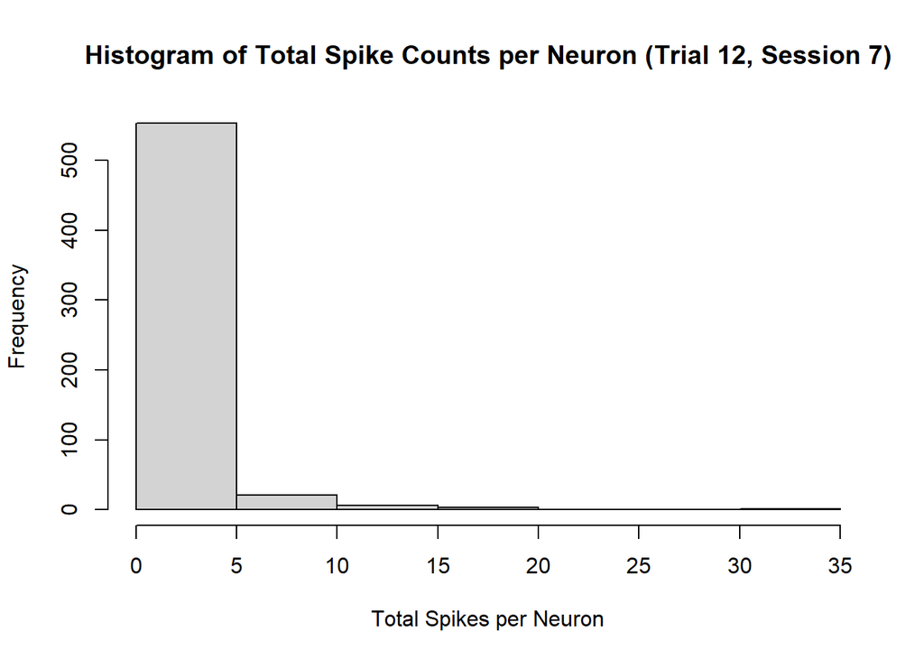

Most neurons exhibit low spike counts, primarily within the 0-5 range, suggesting that the majority of neurons were minimally active during this trial. Only a small fraction of neurons show higher spike counts (>10), with frequency decreasing, indicating that highly active neurons are rare.